# TS- Homework 1

Agata Caso

2024-12-03

**First task**: *Stationary vs ergodic*

Let $\epsilon_t \sim GW N(Z, \sigma^2)$, with $GW N(Z, \sigma^2)$ denoting a Gaussian white noise process with:

- Fixed variance $\sigma^2$
- Random mean $Z \sim U[-5, 5]$, where $U$ represents the Uniform distribution.
- $Z$ is not indexed by $t$, thus it does not change with $t$, unlike $\epsilon_t$.
- The processes $\{\epsilon_t\}_{t=-\infty}^{\infty}$ and $Z$ are assumed to be independent. The process of interest is defined as:
  $$X_t = \theta X_{t-1} + \epsilon_t$$

**a)** We first want to check whether and when the process is stationary. Using the definition of weak stationarity, prove that the process $\{X_t\}_{t=-\infty}^{\infty}$ has constant mean, variance and autocovariance function when $|\theta| < 1$. Intuitively, if the process is stationary, then the value of Z determines the equilibrium state of the process. Note: As the proof will involve two nested random quantities, you may need to use the Law of Total Expectations and the Law of Total Variance.

We know that the conditions for a process to be weak stationary are:

1. $\mathbb{E}(X_t) = \mu < \infty, \, \forall t$ (constant mean)
2. $\text{Var}(X_t) = \gamma_0(t) = \gamma_0 = \sigma^2 < \infty, \, \forall t$ (constant variance)
3. $\text{Cov}(X_t, X_{t+h}) = \gamma_h(t) = \gamma_h, \, \forall t, \forall h$ (covariance depends only on lag $h$, not $t$) **1. MEAN** We start by computing the mean to see whether the time series average is time invariant.

$$\mathbb{E}(X_t) = \mathbb{E}(\theta X_{t-1} + \epsilon_t)$$

Using the linearity of expectation:
$$\mathbb{E}(X_t) = \theta \mathbb{E}(X_{t-1}) + \mathbb{E}(\epsilon_t) =
\theta (X_{t-1}) + \mathbb{E}(Z)$$

At this point we have to consider that the
$$\mathbb{E}(\epsilon_t)$$
depends on the realizations of Z since it behaves as a Uniform random variable. So we have to condition the expectation on Z. In this case we can use the *Law of total expectations*:
$$\mathbb{E}(X) = \mathbb{E}[\mathbb{E}(X|Y)]$$
So we proceed by using this law and by expanding the time series. This allows us to calculate the mean value of a time series up to each point. By doing so, we can follow how the mean of your time series changes with time:

$$\mathbb{E}(X_t) = \mathbb{E}[\mathbb{E}(X_t|Z)]= \mathbb{E}[{E}(\theta
X_{t-1} + \epsilon_t|Z)] = \mathbb{E}[\mathbb{E}(\theta (\theta X_{t-2}
+ \epsilon_{t-1}) + \epsilon_t))|Z] =
\mathbb{E}[\mathbb{E}(\theta^2(\theta X_{t-3} + \epsilon_{t-2}) +
\epsilon_{t-1} + \epsilon_t)|Z]$$

As we can see, if we continue to expand the series we have a succession of past errors till time t and we can represent it as a geometric summation. The reason behind this mathematical choice is that there is a succession of numbers such that the ratio of an element to its preceding one is always constant. So, the process becomes:
$$\mathbb{E}[{E}(\sum_{i=0}^{\infty}\theta^i X_{t-i} + \theta^i
\epsilon_{t-i})|Z]$$
The first term
$$\sum_{i=0}^\infty \theta^i X_{t-i}$$
can be posed as equal to 0 when $|\theta|<1$ beacause it converges geometrically and it wouldn’t influence the time series. Specifically, when $i$ increases the contribution of each $X_{t-i}$ will diminish over time. Since $\epsilon_t$ and $\theta^i$ are independent, the second term
$$\mathbb{E}(\sum_{i=0}^{\infty}\theta^i \epsilon_t)$$
can be rewritten as:
$$\mathbb{E}(\sum_{i=0}^{\infty}\theta^i){E}(\epsilon_{t-i})$$
Considering that the geometric series computed in the first expectation will converge to $\frac{1}{1-\theta}$ when $|\theta|<1$, we can simplify like this:
$$\frac{1}{1-\theta} \mathbb{E}(\epsilon_{t-i})$$
From the assumptions made in the assignment’s task $\epsilon_t$ has mean equal to $Z \sim U[-5, 5]$, so we can use the expected value of a generic uniform
$$\mathbb{E}(X) = \frac{a + b}{2}$$
that in this case is:
$$\mathbb{E}(Z) = \frac{-5 + 5}{2} = 0$$
$$\mathbb{E}(\frac{1}{1-\theta}Z) = \mathbb{E}(\frac{Z}{1-\theta}) = 0$$
So we can conclude that the process is centered around 0 and the mean is constat over time. Basically, we can make a first assumption of stationarity.

**VARIANCE** Now we can see if the second condition is met analysing the variance. Since we have to condition on Z, we can use the *law of total variance*. This latter states that the variance of a random variable X condioned on another random varible Y can be written like this:

$$\text{Var}(Y) = \mathbb{E}[\text{Var}(Y | X)] + \text{Var}(\mathbb{E}[Y
| X])$$

Using this Law, we can write our variance like this:

$$\text{Var}(X_t) = \mathbb{E}_Z[\text{Var}(X_t | Z = z)] +
\text{Var}_Z[\mathbb{E}(X_t | Z = z)]$$

Proceeding with the calculations, we know that
$$\mathbb{E}[Z]=0$$
and
$$\text{Var}(Z) = \frac{(b-a)^2}{12}=
\frac{100}{12}$$
:

$$\text{Var}(X_t) = \mathbb{E}_Z[\text{Var}(X_t|Z=z)] +
\frac{25}{3}[\frac{Z}{1-\theta}]$$

We can focus on the first term.
$$\mathbb{E}_Z[\text{Var}((\sum_{i=0}^{\infty}\theta^i X_{t-i} + \theta^i
\epsilon_{t-i})|Z)]$$
For the same reasons as before we can also not consider the first term.

$$\mathbb{E}_Z[\text{Var}(\sum_{i=0}^{\infty}\theta^i
X_{t-i}|Z)+\text{Var}(\theta^i \epsilon_{t-i})|Z))]=
\mathbb{E}_Z[\frac{1}{1-\theta^2}\sigma^2]$$
So the final result is:

$$\text{Var}(X_t) = \mathbb{E}_Z[\frac{\sigma^2}{1-\theta^2}] +
\frac{25}{3}[\frac{Z}{1-\theta}]
= \frac{\sigma^2}{1-\theta^2} + \frac{25}{3}[\frac{Z}{1-\theta}]$$

The term $1-\theta^2$ ensures that the variance is constant when $|\theta| < 1$. As a last proof of the process’ stationarity we can compute the autocovariance.

**AUTOCOVARIANCE**

The autocovariance of a time series is given by:
$$\gamma_{t,t+h} = \mathbb{E}[(X_t - \mu_t)(X_{t+h} - \mu_{t+h})] =
\gamma_h]$$

In our case we have that for $t$:
$$X_t = \sum_{i=0}^{\infty}\theta^i X_{t-i} + \theta^i \epsilon_{t-i} =
\sum_{i=0}^{\infty}\theta^i \epsilon_t$$
and for $t+h$ we get:
$$X_t = \theta^h X_t + \sum_{i=0}^{h-1} \theta^i \epsilon_{t+h-i}$$
So we can rewrite the autocovariance substituting these definitions as follows:
$$\text{Cov}\left(X_t, \theta^h X_t + \sum_{i=0}^{h-1} \theta^i
\epsilon_{t+h-i} \right)$$
We want to express everything with respect to $X_t$ and since it doesn’t depend on the error term $\epsilon_{t+h-i}$, we have that:

$$\text{Cov}(X_t, X_{t+h}) = \text{Cov}(X_t, \theta^h X_t) = \theta^h
\text{Cov}(X_t, X_t) = \theta^h \text{Var}(X_t) = \theta^h \gamma_0$$
and since $\gamma_0$ is the variance, we can substitute the one we have computed beforehand:
$$= \theta^h \left( \frac{\sigma^2}{1 - \theta^2} + \frac{1}{(1 -
\theta)^2} 10^{12} \right), \quad \forall |\theta| < 1$$
The term $\theta^h$ leads to a decreasing autocovariance for increasing $h$. The stationarity is ensured and confirmed also here for $|\theta| < 1$.

**b)**To assess ergodicity, let us now focus on the autocorrelation function. Show that:

$$\rho_h > 0, \, \forall h$$

This contrasts with the intuitive idea of an ergodic setting. Intuitively, while stationarity refers to the presence of an equilibrium state, ergodicity tells us whether the equilibrium is unique (given $\theta$).

Since we have proved that
$$\text{Cov}(X_t, X_{t+h}) = \theta^h \text{Var}(X_t)$$
The autocorrelation function $\rho_h$ is:

$$\rho_h = \frac{\text{Cov}(X_t, X_{t+h})}{\text{Var}(X_t)} =
\frac{\gamma_h}{\gamma_0} = \theta^h$$

Since $Z$ is randomly drawn from a uniform distribution and does not vary over time, the time average of $X_t$ would depend on the realization of $Z$. Therefore, the process is not ergodic because the time averages would not converge to a single value across all realizations of $Z$, implying non-ergodicity.

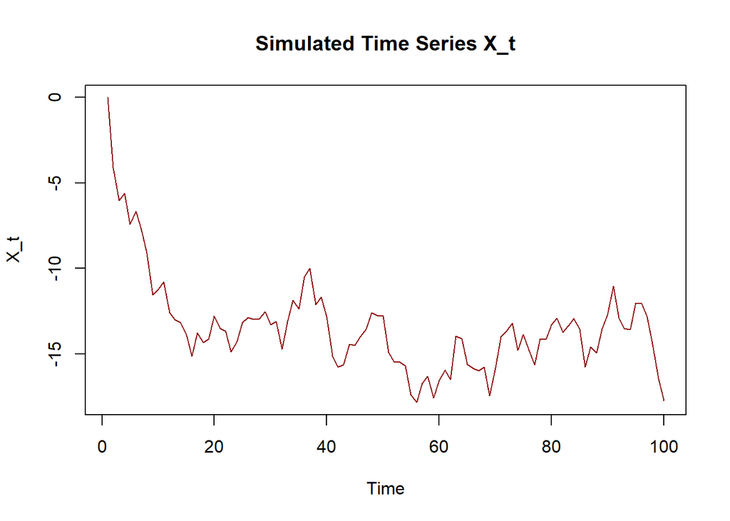

```r
# Define parameters
set.seed(18092001)
sigma2 <- 1
theta <- 0.9
T <- 100
Z <- runif(1, min = -5, max = 5)
epsilon_t <- rnorm(T, mean = Z, sd = sqrt(sigma2))
# Compute the time series
X_t <- numeric(T)
for (t in 2:T) {
  X_t[t] <- theta * X_t[t - 1] + epsilon_t[t]
}
X_t_ts <- ts(X_t)
plot(X_t_ts, main = "Simulated Time Series X_t", ylab = "X_t", xlab = "Time",
     col = "darkred")
```

```r
empirical_mean <- mean(X_t)
empirical_mean
```

```
## [1] -13.37467
```

```r
empirical_variance <- var(X_t)
empirical_variance
```

```
## [1] 8.15787
```

```r
theoretical_mean <- 0
theoretical_mean
```

```
## [1] 0
```

```r
theoretical_variance <- sigma2 / (1 - theta^2) + 25/3*(Z/ (1-theta))
theoretical_variance
```

```
## [1] -103.5602
```

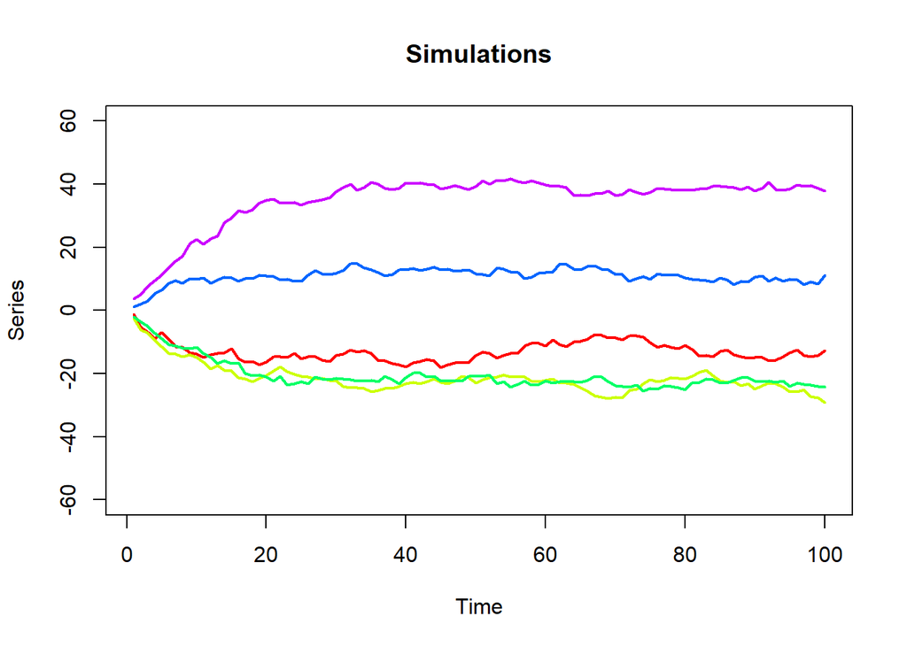

```r
set.seed(18092001)
N = 5
X = matrix(NA, ncol = T, nrow = N)
for (n in 1:N){
      z = runif(1,min=-5,max=5)
  for(t in 2:T){
    epsilon = rnorm(n=T,mean=z,sd=sigma2)
    X[n,1] = z
    X[n,t] = theta*X[n,t-1] + epsilon[t]
  }
}
X_sim_ts=ts(X)
colors <- rainbow(N)
plot(X_sim_ts[1,], type = "l", col = colors[1], lwd = 2, ylim= c(-60,60),main ="Simulations", xlab="Time", ylab="Series")
for(n in 2:N){
  points(X_sim_ts[n,], type = "l", col = colors[n], lwd="2")
}
```

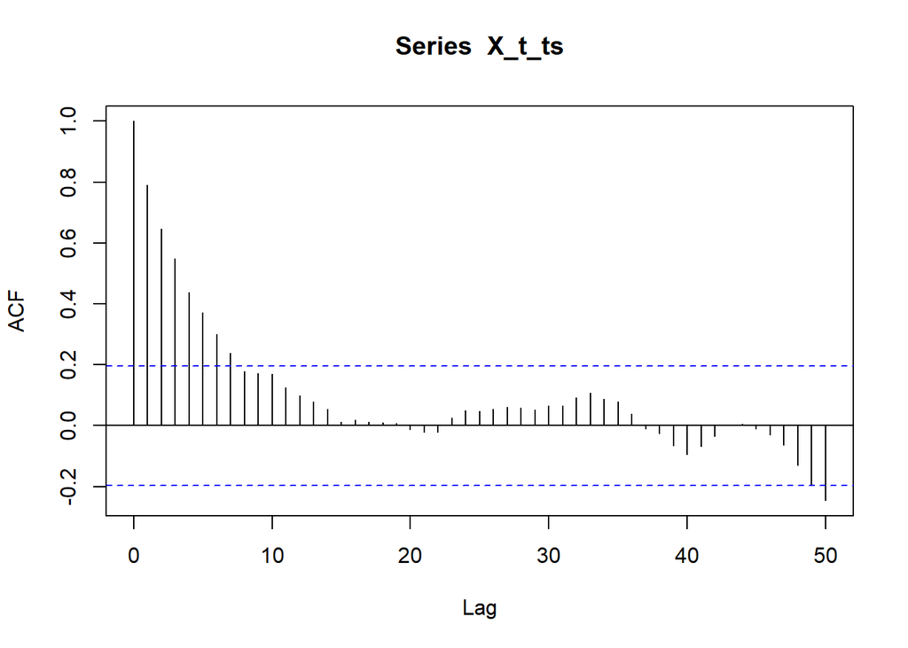

```r
autocorrelation_function = acf(X_t_ts, lag.max = 50)
```

From the autocorrelation function plot we can see that at small lags the correlation is positive and tends to decay for larger lags. A process is ergodic if time averages converge to ensemble averages. Since $Z$ is randomly drawn from a uniform distribution and does not vary over time, the time average of $X_t$ would depend on the realization of $Z$. Therefore, the process is not ergodic because the time averages would not converge to a single value across all realizations of $Z$, implying non-ergodicity.

**Autocorrelation Estimator $\hat{\rho}_h$**

The estimator $\hat{\rho}_h$ likely refers to the sample autocorrelation at lag $h$, which is used to estimate the correlation structure between $X_t$ and $X_{t+h}$. The estimator for the autocorrelation at lag $h$ is typically computed as:

$$\hat{\rho}_h = \frac{\hat{\text{Cov}}(X_t,
X_{t+h})}{\hat{\text{Var}}(X_t)}$$

where: - $\hat{\text{Cov}}(X_t, X_{t+h})$ is the sample covariance between $X_t$ and $X_{t+h}$, - $\hat{\text{Var}}(X_t)$ is the sample variance of $X_t$.

**Consistency of $\hat{\rho}_h$**

For the estimator $\hat{\rho}_h$ to be consistent, it must converge to the true autocorrelation $\rho_h$ as the sample size $T$ tends to infinity.

1. For weakly stationary processes, the autocorrelation function $\rho_h$ does not depend on time. In this case, the estimator $\hat{\rho}_h$ is consistent for each fixed realization of $Z$. However, since $Z$ itself is random, the average autocorrelation across different realizations will not converge to a single value, violating ergodicity and causing non-consistency in the sample autocorrelation over multiple simulations.
2. The process $X_t$ depends on the random mean $Z$, introducing variability in the autocorrelation structure across different realizations of $Z$. For each realization of $Z$, the process may be weakly stationary, but since $Z$ is random, the autocorrelation will vary across simulations. Hence, $\hat{\rho}_h$ will not converge to a single value across different realizations of $Z$, violating consistency across simulations.

### Conclusion

- **Stationarity:** The process can be weakly stationary for a fixed value of $Z$, but it is not stationary in the general case because $Z$ is random.
- **Ergodicity:** The process is not ergodic due to the random mean $Z$, as different realizations of $Z$ lead to different dynamics for $X_t$.
- **Consistency of** $\hat{\rho}_h$: The estimator $\hat{\rho}_h$ will be consistent for each fixed realization of $Z$, but it will not be consistent over time or across different realizations of $Z$, meaning it will not give the same autocorrelation across different simulations.

Ask your mate to repeat the tossing process for $T = 100$ rounds and record the outcome at each round $t$. Now, define your process of interest $X_t$, $t = 1, \dots, T$, as a linear combination of the outcomes $S$ obtained from the previous 2 tosses/rounds (i.e., at $t - 1$ and $t - 2$) with coefficients $\alpha_1$ and $\alpha_2$, plus the outcome at the current toss (round $t$):

$$X_t = S_t + \alpha_1 S_{t-1} + \alpha_2 S_{t-2} .$$
**a)** Since the process is given by a linear combination of the outcomes at each step I would choose a Moving average model. In this case I’ve interpreted the outcomes as the errors left at each coin toss. For what oncerns the distribution of the errors I would choose a binomial distribution since the process is based on coin tosses. **b)** Comment on the (weak) stationarity of $X_t$, by computing its mean, variance, and autocorrelation function (ACF) for lags $h > 0$. For the mean we have to consider that the linear combinations $\S_t$ follow the mean and variance of a binomial random variable:
$$\mathbb{E}(X) = np$$
and
$$\text{Var} = np(1-p)$$
**MEAN**
$$\mathbb {E}(X_t) = \mathbb{E}(S_t) + \mathbb{E}(\alpha_1 S_{t-1}) +
\mathbb{E}(\alpha_2 S_{t-2})) = np + \alpha_1 \mathbb{E}(S_{t-1}) +
\alpha_2 \mathbb{E}(S_{t-2}) = np + \alpha_1 (np) + \alpha_2 (np)$$
We know that $\ p=0.5$ and $n=2$ because we toss 2 coins at each of the 100 trials. We can rewrite the mean as:
$$\mathbb{E}(X_t) = 2 \cdot 0.5\cdot (1- \alpha_1 + \alpha_2) = 1\cdot (1-
\alpha_1 + \alpha_2)$$

**VARIANCE**
$$\text{Var}(X_t) = \text{Var}(S_t) + \alpha_1\text{Var}(S_{t-1}) +
\alpha_2 \text{Var}(S_{t-2}) = 2 \cdot 0.5 \cdot (1 - 0.5) \cdot (1 +
\alpha_1^2 + \alpha_2^2)$$
Since the coin tosses are i.i.d., the process $X_t$, which is a linear combination of these tosses, will exhibit **weak stationarity**. Specifically: - The mean of $X_t$ will be constant over time, as it depends only on the mean of $S_t$. - The variance of $X_t$ will be constant, as it is a function of the variance of $S_t$. - The autocovariance function of $X_t$ will depend only on the lag between time points and not on the specific time, satisfying the condition for weak stationarity. Thus, the process $X_t$ is weakly stationary.

**AUTOCORRELATION**

To compute the autocorrelation we need $\gamma_1$ and $\gamma_2$. To do that we can use the autocovariance generating function:
$$\gamma(B) = \sigma^2 (1 - \alpha_1 B - \alpha_2 B^2)(1 - \alpha_1 B^{-1}
- \alpha_2 B^{-2})
= \sigma^2 \left[-\alpha_2 B^2 - \alpha_1 (1 - \alpha_2) B^{-1} + (1 +
\alpha_1^2 + \alpha_2^2) - \alpha_1 (1 - \alpha_2) B - \alpha_2 B^2
\right]$$

After some computations,
$$\gamma_0 = (1+ \alpha_1^2 + \alpha_2^2)\ 2 \cdot 0.5 \cdot (1 - 0.5)
\cdot (1 + \alpha_1^2 + \alpha_2^2)$$
$$\gamma_1 = -\alpha_1(1 - \alpha_2)\ 2 \cdot 0.5 \cdot (1 - 0.5) \cdot (1
+ \alpha_1^2 + \alpha_2^2)$$
$$\gamma_2 = -\alpha_2 \ 2 \cdot 0.5 \cdot (1 - 0.5) \cdot (1 + \alpha_1^2
+ \alpha_2^2)$$
For k > 2
$$\gamma_k = 0$$

The autocorrelation function is:

For $k = 0$ (the autocorrelation at lag 0 is always 1):

$$\rho(0) = \frac{\text{Cov}(X_t, X_t)}{\text{Var}(X_t)} = \frac{n \cdot p
\cdot (1 - p) \cdot (1 + \alpha_1^2 + \alpha_2^2)}{n \cdot p \cdot (1 -
p) \cdot (1 + \alpha_1^2 + \alpha_2^2)} = 1$$

For $k = 1$:

$$\rho(1) = \frac{\text{Cov}(X_t, X_{t-1})}{\text{Var}(X_t)} = \frac{n
\cdot p \cdot (1 - p) \cdot (\alpha_1 + \alpha_1 \alpha_2)}{n \cdot p
\cdot (1 - p) \cdot (1 + \alpha_1^2 + \alpha_2^2)} = \frac{\alpha_1 +
\alpha_1 \alpha_2}{1 + \alpha_1^2 + \alpha_2^2}$$

For $k = 2$:

$$\rho(2) = \frac{\text{Cov}(X_t, X_{t-2})}{\text{Var}(X_t)} = \frac{n
\cdot p \cdot (1 - p) \cdot \alpha_2}{n \cdot p \cdot (1 - p) \cdot (1 +
\alpha_1^2 + \alpha_2^2)} = \frac{\alpha_2}{1 + \alpha_1^2 + \alpha_2^2}$$

For $k > 2$:

$$\rho(k) = 0$$

which cuts off after lag 2.

Although the process is stationary, it is **not ergodic** because the time averages of $X_t$ may not converge to its expected value due to the dependency on the specific realization of the coin toss sequence. Each realization of the coin toss sequence can lead to a different long-run behavior, meaning the time averages do not necessarily represent the ensemble averages of the process. Therefore, the process $X_t$ is **not ergodic**.

**c)**Using the Yule-Walker equations seen in class, compute its PACF for lags $h = 1, 2, 3$.

$$\phi_{11} = \rho_1 = \frac{\text{Cov}(X_t, X_{t-1})}{\text{Var}(X_t)} =
\frac{n \cdot p \cdot (1 - p) \cdot (\alpha_1 + \alpha_1 \alpha_2)}{n
\cdot p \cdot (1 - p) \cdot (1 + \alpha_1^2 + \alpha_2^2)} =
\frac{\alpha_1 + \alpha_1 \alpha_2}{1 + \alpha_1^2 + \alpha_2^2}$$

$$\phi_{22} = \frac{\rho_2 - \rho_1^2}{1 - \rho_1^2} = \frac{\gamma(2) -
\phi(1) \cdot \gamma(1)}{\gamma(0) - \phi(1) \cdot \gamma(1)} = \frac{n
\cdot p \cdot (1 - p) \cdot \alpha_2 - \phi(1) \cdot n \cdot p \cdot (1
- p) \cdot (\alpha_1 + \alpha_1 \alpha_2)}{n \cdot p \cdot (1 - p) \cdot
(1 + \alpha_1^2 + \alpha_2^2) - \phi(1) \cdot n \cdot p \cdot (1 - p)
\cdot (\alpha_1 + \alpha_1 \alpha_2)}$$

$$\phi_{33} = \frac{\rho_1^2 - \rho_1 \rho_2 (2 - \rho_2)}{1 - \rho_1^2 -
2 \rho_1 \rho_2 (1 - \rho_2)} = \frac{\frac{\alpha_2}{1 + \alpha_1^2 +
\alpha_2^2} - \left( \frac{\alpha_1 + \alpha_1 \alpha_2}{1 + \alpha_1^2
+ \alpha_2^2} \right) \cdot \frac{\alpha_2}{1 + \alpha_1^2 + \alpha_2^2}
\left( 2 - \frac{\alpha_2}{1 + \alpha_1^2 + \alpha_2^2} \right)}{1 -
\left( \frac{\alpha_1 + \alpha_1 \alpha_2}{1 + \alpha_1^2 + \alpha_2^2}
\right)^2 - 2 \cdot \frac{\alpha_1 + \alpha_1 \alpha_2}{1 + \alpha_1^2 +
\alpha_2^2} \cdot \frac{\alpha_2}{1 + \alpha_1^2 + \alpha_2^2} \left( 1
- \frac{\alpha_2}{1 + \alpha_1^2 + \alpha_2^2} \right)}$$

**d)**Choose the values for the fixed coefficients α1 and α2 which define the influence of Xt on the past outcomes, and explain the choice you made. I’ve chosen $\alpha_1$ = 0.5 and $\alpha_2$ = 0.3 because more recent observations can have a greater influence on the time series so they have to be weighted more. **e)**

```r
set.seed(123)
T <- 100
alpha1 <- 0.5
alpha2 <- 0.3


S_t <- c(1,0,1,2,0,2,0,0,1,0,1,1,0,1,1,0,0,0,0,1,0,1,1,1,1,0,0,2,1,0,1,1,1,1,2,1,1,1,1,2,0,1,1,1,1,0,2,1,2,0,1,2,0,1,1,1,1,2,1,1,1,1,0,0,0,1,2,0,1,0,1,1,1,1,0,1,0,1,1,0,1,1,0,2,2,1,1,0,2,1,2,0,1,1,0,2,2,0,2,0)
length(S_t)
```

```
## [1] 100
```

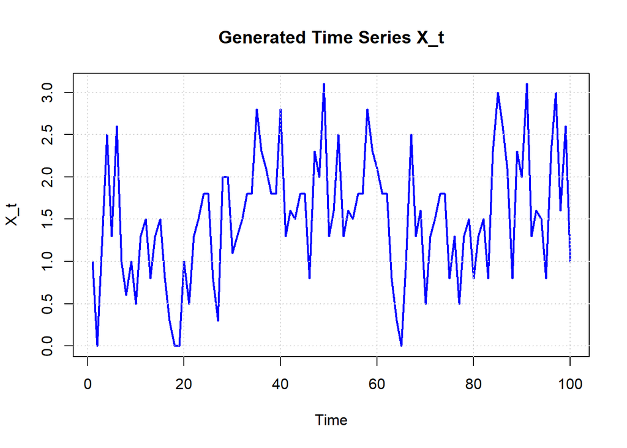

```r
X_t <- S_t
X_t[3:length(S_t)] <- S_t[3:length(S_t)] +
                     alpha1 * S_t[2:(length(S_t)-1)] +
                     alpha2 * S_t[1:(length(S_t)-2)]

plot(X_t, type = "l", col = "blue", lwd = 2,
     xlab = "Time", ylab = "X_t",
     main = "Generated Time Series X_t")
grid()
```

```r
n = 2
p = 0.5
empirical_mean2 <- mean(X_t)
empirical_mean2
```

```
## [1] 1.519
```

```r
theoretical_mean2 <- n*p*(1 - alpha1 + alpha2)
theoretical_mean2
```

```
## [1] 0.8
```

```r
empirical_var2 <- var(X_t)
empirical_var2
```

```
## [1] 0.5435747
```

```r
theoretical_var2 <- n*p*(1-p)*(1 + alpha1^2 + alpha2 ^2)
theoretical_var2
```

```
## [1] 0.67
```

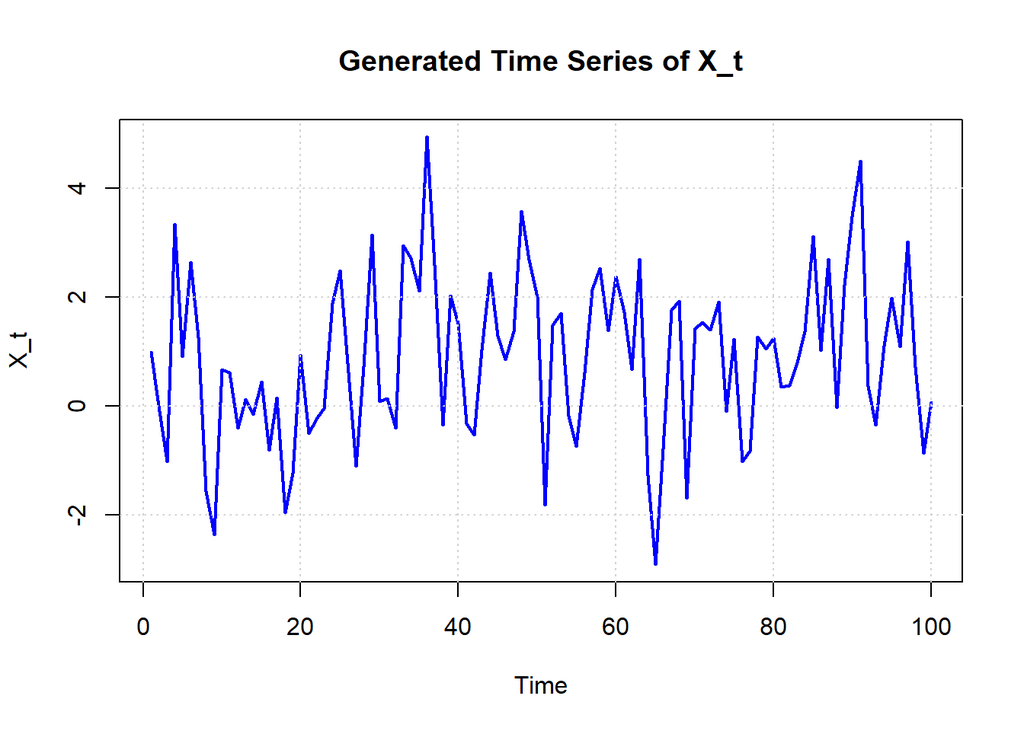

```r
alpha_1_new = 1.5
for (t in 3:T) {
  X_t[t] <- alpha_1_new * S_t[t-1] + alpha2 * S_t[t-2] + S_t[t] + epsilon_t[t]
}
plot(X_t, type = "l", col = "blue", lwd = 2,
     main = "Generated Time Series of X_t",
     xlab = "Time", ylab = "X_t")
grid()
```

```r
empirical_mean2 <- mean(X_t)
empirical_mean2
```

```
## [1] 0.9032431
```

```r
theoretical_mean2 <- n*p*(1 - alpha_1_new +alpha2)
theoretical_mean2
```

```
## [1] -0.2
```

```r
empirical_var2 <- var(X_t)
empirical_var2
```

```
## [1] 2.271788
```

```r
theoretical_var2 <-  n*p*(1-p)*(1 + alpha_1_new^2 + alpha2^2)
theoretical_var2
```

```
## [1] 1.67
```

For reference I have collaborated on the homework with: Sara Ponzo, Alessandra Campanella, Giuseppina Orefice and Marco Cavallo.